# explore English priority species abundance index to2023

# Unsmoothed trends

An easier way to get the unsmoothed line for each group is to use the WBI method for creating an MSI.

Let’s see if this is a sensible way to plot unsmoothed trends.

For this we need to get a version of the dataset with interpolated values

Read in the script of tidying and indicator functions

```r
source("/data/notebooks/rstudio-esaiukpsi26/tidy_functions.R")
```

Read in species smoothed time-series This involves

- Converting to measurement scale
- Expanding the grid so that all spp/yr combinations have a row
- Interpolating across any missing values within a species time-series
- Holding the final value constant where a ts ends before 2024

```r
data1 <- read.csv("/data/tidy_data/d6a_spp_ts_engto24_Smoothed_unsmVP_120326.csv")

#convert index2 back to measurement scale so tidying rqd and tidy_d functions work properly
data24 <- data1 %>%
  mutate(index = exp(index2),
         common_name = NA) %>%
dplyr::rename(scientific_name = species)

#run tidying report
tidy_rpt24 <- tidying_rqd(data24)

#expand grid to add missing species year combinations, interpolate missing values within time-series and hold the final value constant where time-series end before the final year. There will be no zeros in the dataset at this stage
data24_geom <- tidy_d(data = data24, tidy_rpt = tidy_rpt24 , exp.g = "Y", interp = "Y", exp_tail = "Y") %>%
  rescale(index, Index_root = 1) %>% #rescale index
  group_by(scientific_name) %>%
  fill(group, .direction = "updown") %>%
  fill(survey, .direction ="updown")  # add group and survey info into additional rows


#calculate geometric mean all and by group
all_geo <- indFun1(data24_geom, index, grp_col = scientific_name) %>%
  mutate(group = "all")
```

```
## `mutate_if()` ignored the following grouping variables:
## • Column `scientific_name`
```

```r
grp_geo <- ddply(filter(data24_geom, !group %in% c("bumblebees", "fw invertebrates", "vascular plants")),
                 .(group), indFun1, ind_col = index, grp_col = scientific_name) %>%  # remove small groups, bumbles, fw inv and plants
  full_join(all_geo) %>%
  dplyr::rename(unsmoothedMSI = comp_index) %>%
  dplyr::mutate(unsmoothedMSI = unsmoothedMSI*100)
#merge with freeman model outputs
df <- df %>%
  merge(grp_geo, by.x=c("Year", "group"), by.y = c("year", "group"), all = TRUE)
```

# Plot indicator

For simplicity we will plot only the smoothed M index.

## Headine indicator

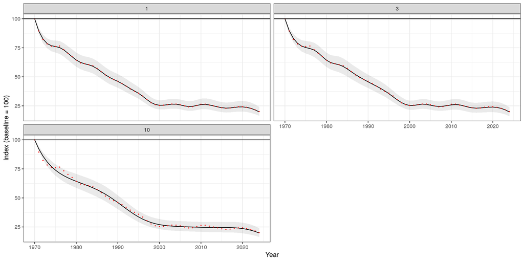

```r
gp0 <- ggplot(data = subset(df, group == "all"), aes(x = Year)) +
  geom_ribbon(aes(ymin = lowerCI.M, ymax = upperCI.M), alpha = 0.1) +
  geom_line(aes(y  = Index.M)) +
  geom_point(aes(y = unsmoothedMSI), col="red", size = .2) +
  facet_wrap(~ypk, nrow=2) +
  geom_hline(yintercept = 100) +
  ylab("Index (baseline = 100)") +
  theme_bw()
gp0
```

Each panel here represents a different degree of smoothing.

You can see clearly that, in the case with one knot per three years, the smoothed and unsmoothed lines are virtually identical. The impact of the smoothing becomes progressively clear as the smoothing window (number of years per knot) increases.

The red dots here are from the WBI method for calculating the geometric mean. It’s the same data plotted in all the panels. We would expect this to map on very closely to the 1 year per knot example.

## By taxon

Plot separately for each taxon.

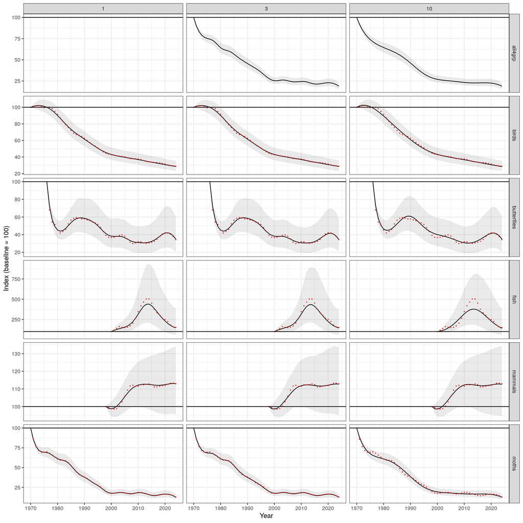

```r
gp1 <- ggplot(data = df, aes(x=Year)) +
  geom_ribbon(aes(ymin=lowerCI.M, ymax=upperCI.M), alpha = 0.1) +
  geom_line(aes(y=Index.M)) +
  geom_point(aes(y=unsmoothedMSI), col="red", size = .2) +
  facet_grid(group~ypk, scales = "free_y") +
  ylab("Index (baseline = 100)") +
  theme_bw()

gp1  %+% subset(df, !group %in% c("all", "all_five_yr", "all_ten_yr")) +
  geom_hline(yintercept = 100)
```

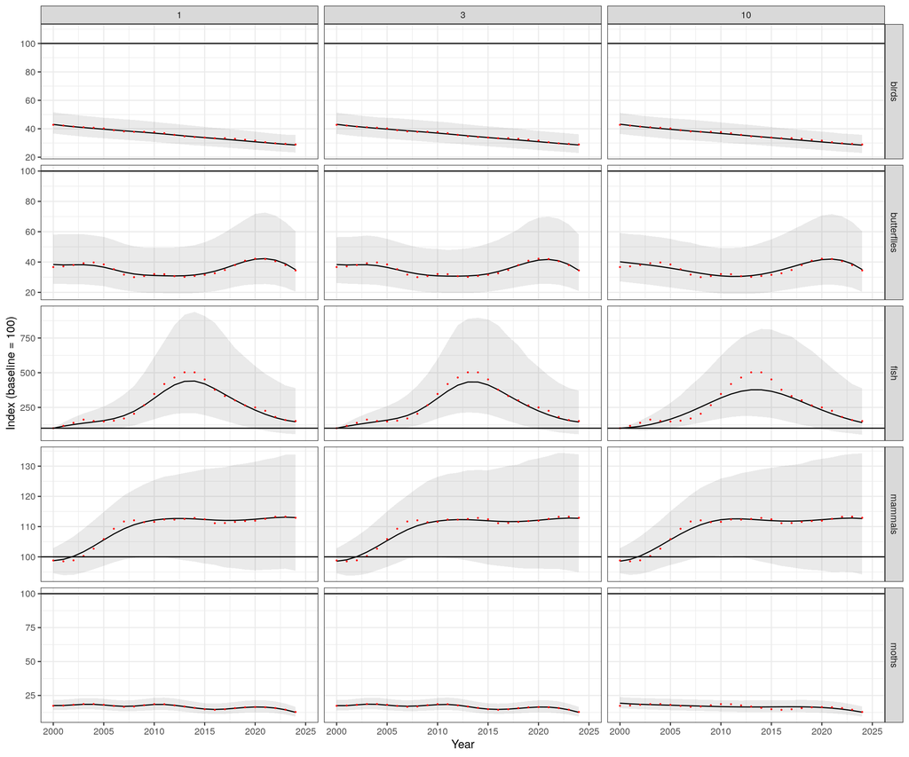

```r
minYr <- 2000
gp1  %+% subset(df, !group %in% c("all", "all_five_yr", "all_ten_yr", "all4grp")) +
  geom_hline(yintercept = 100)+
  xlim(c(minYr, 2025))
```

In these plots, the uncertainty is expressed relative to the baseline (1970 for some groups). I could re-calculate the uncertainty ribbons so that they’re measuring change relative to this new baseline.

plot re-baselined all species 3ypk

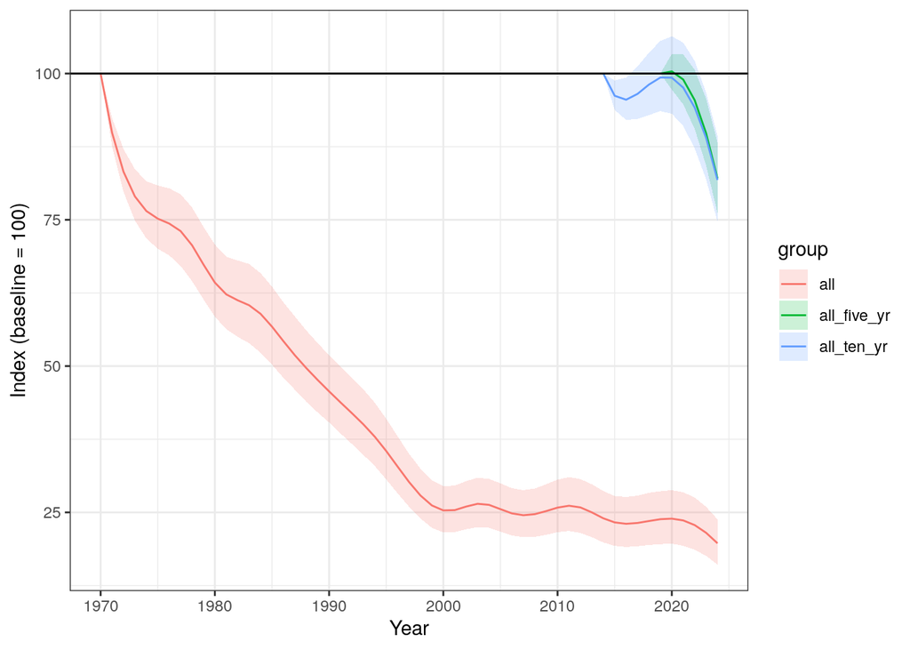

```r
ggplot(data = subset(df, group %in% c("all", "all_five_yr", "all_ten_yr") & ypk == 3), aes(x=Year)) +
  geom_ribbon(aes(ymin = lowerCI.M, ymax = upperCI.M, fill = group), alpha = 0.2 ) +
  geom_line(aes(y = Index.M, col = group)) +
  geom_hline(yintercept = 100) +
  ylab("Index (baseline = 100)") +
  scale_x_continuous(breaks = breaks_pretty()) +
  theme_bw()
```

rescale to final year to make comparison easier and look post 2010

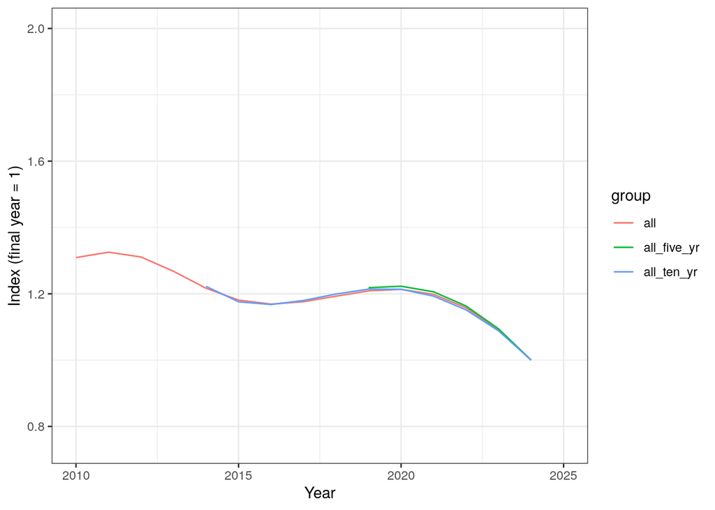

```r
rb <- df %>%
  filter(group == "all" & ypk == 3| group ==  "all_five_yr"| group == "all_ten_yr" ) %>%
  group_by(group) %>%
  mutate(rel_final = Index.M/Index.M[Year == 2024])

ggplot(rb, aes(x=Year)) +
  geom_line(aes(y = rel_final, col = group)) +
  ylab("Index (final year = 1)") +
  scale_y_continuous( limits = c(.75, 2)) +
  theme_bw() +
  xlim(2010, 2025)
```

Differences between the different numbers of knots are not especially clear.

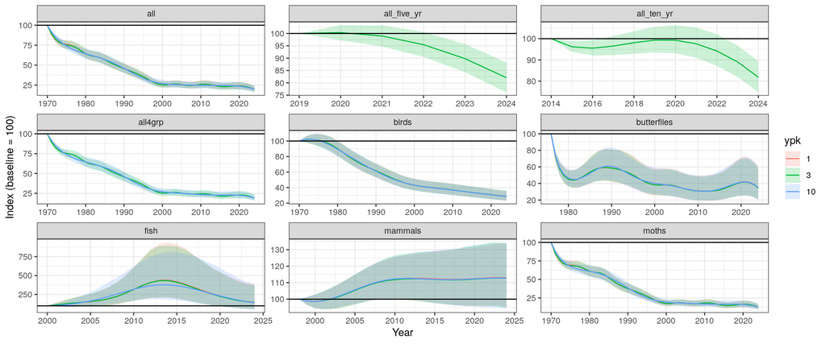

For most groups, the choice of smoothing makes very little difference.

Now overlay the different Mprime (unsmoothed indicator) lines

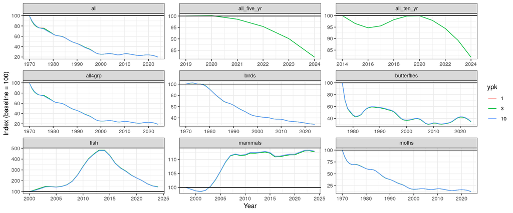

This shows that the “unsmoothed” line (M.prime) is almost completely insensitive to the number of knots. This is particularly true for the taxon-specific trends, but less true of the all-species plot.

## Official plot

Defra has decided that the preferred option is to present the `ypk = c(10, 3)` lines on the same plot, with `ypk = 1` as points representing the unsmoothed trend.

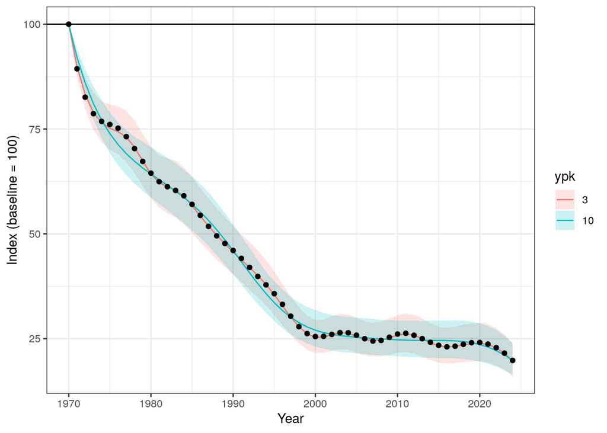

```r
prodplotAll <- ggplot(data = subset(df, group %in% c("all") & ypk %in% c(3, 10)),
                      aes(x=Year)) +
  geom_ribbon(aes(ymin=lowerCI.M, ymax=upperCI.M, fill=ypk), alpha = 0.2) +
  geom_line(aes(y=Index.M, col=ypk)) +
  geom_point(data = subset(df, group %in% c("all") & ypk == 1),
             aes(x=Year, y=Index.M), col = "black") +
  geom_hline(yintercept = 100) +
  ylab("Index (baseline = 100)") +
  scale_x_continuous(breaks = breaks_pretty()) +
  theme_bw()
prodplotAll
```

The unsmoothed (1 knot per year) line is almost identical to the 3 years-per-knot line. This is not unexpected as the time-series are pre-smoothed with a period of 3ypk

Now for each taxonomic group

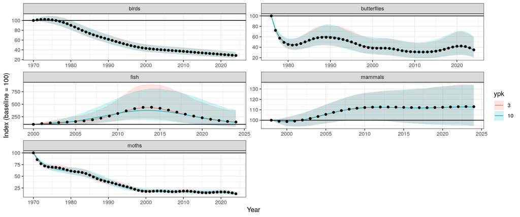

```r
prodplotTx <- ggplot(data = subset(df, !group %in% c("all", "all_five_yr", "all_ten_yr", "all4grp") & ypk %in% c(3, 10)),
                      aes(x=Year)) +
  geom_ribbon(aes(ymin=lowerCI.M, ymax=upperCI.M, fill=ypk), alpha = 0.2) +
  geom_line(aes(y=Index.M, col=ypk)) +
  geom_point(data = subset(df, !group %in% c("all") & ypk == 1),
             aes(x=Year, y=Index.M), col = "black") +
  geom_hline(yintercept = 100) +
  ylab("Index (baseline = 100)") +
  scale_x_continuous(breaks = breaks_pretty()) +
  theme_bw()

prodplotTx + facet_wrap(~group, nrow=4, scales = "free")
```

# Change metrics

Now summarise the long-term, short-term and instantaneous change for each version of the index.

## Long term

The long term trend is the same, regardless of the number of knots. Let’s report these as % change since the baseline.

```r
LongTerm <- subset(df, ypk == 10, select = !grepl("prime", names(df))) %>%
  group_by(group) %>%
  filter(Year == max(Year)) %>%
  mutate(Index.M = signif(Index.M - 100, 2),
         lowerCI.M = signif(lowerCI.M - 100, 2),
         upperCI.M = signif(upperCI.M - 100, 2)) %>%
  dplyr::rename(BestEst = Index.M,
                lowerCI = lowerCI.M,
                upperCI = upperCI.M)

LongTerm[,c(6,5,2:4)]
```

```
## # A tibble: 7 × 5
## # Groups:   group [7]
##   ypk   upperCI group       BestEst lowerCI
##   <fct>   <dbl> <chr>         <dbl>   <dbl>
## 1 10        -76 all             -80   -84
## 2 10        -77 all4grp         -81   -84
## 3 10        -64 birds           -71   -77
## 4 10        -40 butterflies     -65   -80
## 5 10        290 fish             40   -47
## 6 10         34 mammals          13    -5.8
## 7 10        -83 moths           -87   -91
```

The lower and upper CI represent the 95% credible intervals. This means we are 95% confident that the true value lies within this range.

## Short Term assessment

```r
TimeboundChange <- function(x, metric="ind", t=5){
  temp  <- subset(df, group == x["group"][[1]] & ypk == as.numeric(x["ypk"][[1]]))
  Y1    <- max(temp$Year, na.rm=TRUE)
  Y0    <- Y1 - t
  temp2 <- subset(temp, Year %in% c(Y0, Y1))
  stat  <- diff(temp2$Index.M)
  if(metric == "pc"){ # convert to a percentage
    stat <- 100 * stat / temp2[temp2$Year==Y0,"Index.M"]
  }
  round(stat,1)
}

change <- apply(pars, 1, TimeboundChange, metric="ind", t=5)
ShortTerm1 <- cbind(pars[c(1,2,5)], change=change)
(ShortTerm1 <- acast(ShortTerm1, group~ypk, value.var="change"))
```

```
##                  1      3     10
## all           -4.2   -4.1   -4.2
## all_five_yr     NA  -17.9     NA
## all_ten_yr      NA  -17.5     NA
## all4grp         NA   -3.7   -3.8
## birds         -2.9   -2.9   -2.8
## butterflies   -5.4   -5.4   -5.3
## fish        -118.1 -113.0 -120.5
## mammals        0.8    0.9    0.6
## moths         -3.6   -3.5   -3.8
```

Each column represents a different degree of smoothing (number of knots per year). Note that, when pre-smoothing happens on the log scale, there is very little variation in the 5 year trend.

Values in this table are relative to the baseline conditions in the first year. Let’s repeat these calculations but calculate change as a percentage of the value five years ago.

```r
change <- apply(pars, 1, TimeboundChange, metric="pc", t=5)
ShortTerm1 <- cbind(pars[c(1,2,5)], change=change)
(ShortTerm1 <- acast(ShortTerm1, group~ypk, value.var="change"))
```

```
##                 1     3    10
## all         -17.6 -17.3 -17.5
## all_five_yr    NA -17.9    NA
## all_ten_yr     NA -17.6    NA
## all4grp        NA -16.4 -16.7
## birds        -9.1  -9.2  -9.0
## butterflies -13.4 -13.4 -13.2
## fish        -44.7 -43.9 -46.2
## mammals       0.7   0.8   0.5
## moths       -22.3 -21.9 -23.0
```

## Final year change

Finally, let’s look at the value of the first derivative in the final year. Again, we’ll express this as a percentage of the previous year’s value.

```r
finalYrChange <- function(mod){
    modsum <- attr(mod, "model")$summary
    logLam <- modsum[grepl("logLambda", dimnames(modsum)[[1]]),]
    ll <- logLam[nrow(logLam),c(1,3,7,11)]
    ll[1:3] <- 100 * (exp(ll[1:3]) - 1)
    signif(ll, 2)
}

# log scale pre-smoothing
FinalYr <- t(sapply(output, finalYrChange))
(FinalYr <- cbind(pars[,c(1,2,3)], FinalYr))
```

```
##                                              group ypk n.knots    mean  2.5%
## all_10ypk_L_d6_4grp_5kit_260312.rds        all4grp  10       6  -6.500  -8.2
## all_10ypk_L_d6_5kit_260312.rds                 all  10       6  -6.100  -7.7
## all_1ypk_L_d6_5kit_260312.rds                  all   1      55  -8.100 -10.0
## all_3ypk_L_d6_4grp_5kit_260312.rds         all4grp   3      18  -8.800 -11.0
## all_3ypk_L_d6_5kit_260312.rds                  all   3      18  -8.300 -10.0
## all_3ypk_L_d6_five_yr_5kit_260312.rds  all_five_yr   3       2  -8.600 -11.0
## all_3ypk_L_d6_ten_yr_5kit_260312.rds    all_ten_yr   3       4  -8.100 -10.0
## birds_10ypk_L_d6_5kit_260312.rds             birds  10       6  -1.800  -3.6
## birds_1ypk_L_d6_5kit_260312.rds              birds   1      55  -1.800  -3.8
## birds_3ypk_L_d6_5kit_260312.rds              birds   3      18  -1.900  -3.9
## butterflies_10ypk_L_d6_5kit_260312.rds butterflies  10       5  -9.700 -14.0
## butterflies_1ypk_L_d6_5kit_260312.rds  butterflies   1      49 -10.000 -15.0
## butterflies_3ypk_L_d6_5kit_260312.rds  butterflies   3      16 -10.000 -15.0
## fish_10ypk_L_d6_5kit_260312.rds               fish  10       2 -11.000 -23.0
## fish_1ypk_L_d6_5kit_260312.rds                fish   1      25  -7.300 -20.0
## fish_3ypk_L_d6_5kit_260312.rds                fish   3       8  -7.100 -20.0
## mammals_10ypk_L_d6_5kit_260312.rds         mammals  10       3  -0.140  -2.6
## mammals_1ypk_L_d6_5kit_260312.rds          mammals   1      27  -0.089  -2.4
## mammals_3ypk_L_d6_5kit_260312.rds          mammals   3       9  -0.063  -2.5
## moths_10ypk_L_d6_5kit_260312.rds             moths  10       6  -8.800 -11.0
## moths_1ypk_L_d6_5kit_260312.rds              moths   1      55 -13.000 -16.0
## moths_3ypk_L_d6_5kit_260312.rds              moths   3      18 -13.000 -16.0
##                                         97.5%    f
## all_10ypk_L_d6_4grp_5kit_260312.rds     -4.80 1.00
## all_10ypk_L_d6_5kit_260312.rds          -4.40 1.00
## all_1ypk_L_d6_5kit_260312.rds           -5.80 1.00
## all_3ypk_L_d6_4grp_5kit_260312.rds      -6.90 1.00
## all_3ypk_L_d6_5kit_260312.rds           -6.60 1.00
## all_3ypk_L_d6_five_yr_5kit_260312.rds   -5.80 1.00
## all_3ypk_L_d6_ten_yr_5kit_260312.rds    -5.70 1.00
## birds_10ypk_L_d6_5kit_260312.rds        -0.05 0.98
## birds_1ypk_L_d6_5kit_260312.rds          0.30 0.94
## birds_3ypk_L_d6_5kit_260312.rds          0.25 0.96
## butterflies_10ypk_L_d6_5kit_260312.rds  -4.90 1.00
## butterflies_1ypk_L_d6_5kit_260312.rds   -4.60 1.00
## butterflies_3ypk_L_d6_5kit_260312.rds   -5.10 1.00
## fish_10ypk_L_d6_5kit_260312.rds          2.10 0.95
## fish_1ypk_L_d6_5kit_260312.rds           9.00 0.83
## fish_3ypk_L_d6_5kit_260312.rds           8.60 0.83
## mammals_10ypk_L_d6_5kit_260312.rds       2.30 0.55
## mammals_1ypk_L_d6_5kit_260312.rds        2.40 0.54
## mammals_3ypk_L_d6_5kit_260312.rds        2.40 0.51
## moths_10ypk_L_d6_5kit_260312.rds        -6.30 1.00
## moths_1ypk_L_d6_5kit_260312.rds         -9.80 1.00
## moths_3ypk_L_d6_5kit_260312.rds        -10.00 1.00
```

### Summary of final year updated 10.03.26 SM

In general there is both quantitative and qualitative agreement between the different degrees of smoothing:

- Birds are declining by 1.8to 1.9% pa
- Butterflies are decreasing by 9.7 to 10% pa
- Mammals are decreasing by 0.063 to 0.14% pa
- Moths are decreasing by 8.8 to 13% pa
- Fish are decreasing by 7.1-11% pa
- For “all”, a decrease of 6.1 to 8.3% pa

# Species-level trends

We first need to identify the two “all species” runs

```r
#we need to filter out the 4grp model  and short term model outputs
output     <- output[-c(grep("4grp", names(output)), grep("_yr", names(output)))]
#need to remove 2nd version of all species models and short term models for this to work properly
modelfiles <- modelfiles[-c(grep("4grp", modelfiles), grep("_yr", modelfiles))]
```

```r
getSpTrends <- function(name, n = 0){
  # `n` is an optional variable determing the number of years over which to estimate the trend
  # if zero then the full series is used. If an integer above zero then the final `n` years of the series is used
  mod <- attr(output[[grep(name, modelfiles)]], "model")
  spg <- mod$mean$spgrowth
  estimate <- mod$data$estimate # the raw data. Has one more column than spg

  if(n > 0){
    # short term assessment. Restrict spg to the last n years
    N <- dim(spg)[2]
    spg <- spg[,(N-n):N]
    estimate <- estimate[,(N-n):N]
  } else {
    estimate <- estimate[,-1]
  }

  spMGR <- sapply(1:nrow(spg), function(i){
    rates <- spg[i,!is.na(estimate[i,])]
    mean(rates[-1]) # ignore first value - this is the first year with data so the GR is from other species
  })

  names(spMGR) <- dimnames(estimate)[[1]]
  100*(exp(spMGR)-1)
}
```

run getSpTrends

```r
spTrends <- lapply(c(0, 5), function(n){
  x <- as.data.frame(do.call(cbind, lapply(list("all_3", "all_10"), getSpTrends, n=n)))
  names(x) <- paste0(c("ypk3", "ypk10"), "_", n)
  x
})
spTrends <- do.call(cbind, spTrends)
head(spTrends)
```

```
##                            ypk3_0    ypk10_0     ypk3_5    ypk10_5
## acrocephalus palustris -5.4994381 -5.4993779 -12.234517 -11.998916
## acronicta psi          -0.8624813 -0.8623533   3.442658   3.442664
## acronicta rumicis      -1.1587740 -1.1586065   2.266155   2.265048
## agrochola helvola      -1.6153472 -1.6154048  10.455886  10.452353
## agrochola litura       -3.8170145 -3.8169099 -19.741544 -19.740882
## agrochola lychnidis    -4.0822563 -4.0818686  -7.691422  -7.688848
```

The `ypk3_0` column is the long term trend when smoothed with three knots per year. The `ypk10_5` column is the short term trend (last 5 years) when smoothed with ten knots per year. etc etc. All trends are measured as the mean across years, converted to a percentage increase/decrease in abundance

Take a look at the overall distribution

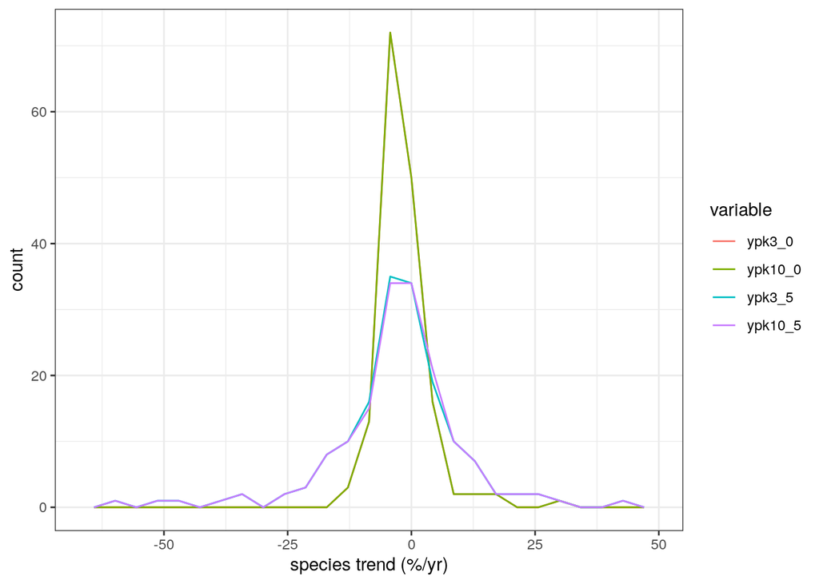

```r
ggplot(data=melt(spTrends)) +
  geom_freqpoly(aes(value, col=variable), bins = 25) +
  xlab("species trend (%/yr)") +
  #xlim(c(-30,30))+
  theme_bw()
```

Some very large values! Let’s look at the quantiles.

```r
pc <-  c(1,5,10,25)
signif(apply(spTrends, 2, quantile, c(pc/100,0.5,sort(1-pc/100)), na.rm=T),2)
```

```
##     ypk3_0 ypk10_0 ypk3_5 ypk10_5
## 1%  -11.00  -11.00  -49.0   -49.0
## 5%   -8.70   -8.70  -23.0   -23.0
## 10%  -6.40   -6.40  -16.0   -16.0
## 25%  -4.50   -4.50   -8.0    -7.7
## 50%  -2.60   -2.70   -2.2    -1.7
## 75%  -0.64   -0.62    2.8     2.9
## 90%   3.20    3.20   10.0    10.0
## 95%   5.90    5.90   15.0    15.0
## 99%  18.00   18.00   28.0    28.0
```

We need to include the `na.rm=T` because there is a small number of species with no data in the last 5 years

Updated 10.03.26 This shows that most species trends are within the range of what we would expect. The short-term trends are absolutely larger than the long-term Again this is what we expect (short term trends are subject to noisy fluctuation). For the long-term trends:

- half of all species are declining between -0.64 to -4.5% per year
- 80% of species are declining by -6.4 to +3.2% pa
- 90% of species are declining by -8.7 to increasing by +5.9% pa
- 98% of species are between a decline of -11 and increase of +18% pa
- There is a small minority of species with extreme trends outside this range There is also a clear tendency for more decreasing species than increasing. Again, this is what we would expect (in the long term)

## Extreme species trends

Take a look at the raw data for the most steeply declining species

```r
head(losers <- subset(spTrends, ypk3_0 < -10))
```

```
##                              ypk3_0   ypk10_0    ypk3_5   ypk10_5
## austropotamobius pallipes -10.87097 -10.87109 -13.62722 -13.62567
## cirrhia gilvago           -10.02140 -10.02136 -48.11325 -48.11160
## graphiphora augur         -10.03461 -10.03450 -34.11534 -34.11274
## mniotype adusta           -10.02176 -10.02170 -58.58789 -58.58735
## orthonama vittata         -11.18941 -11.18932 -40.35141 -40.35274
## osmerus eperlanus         -14.36023 -14.30250 -23.00718 -23.11262
```

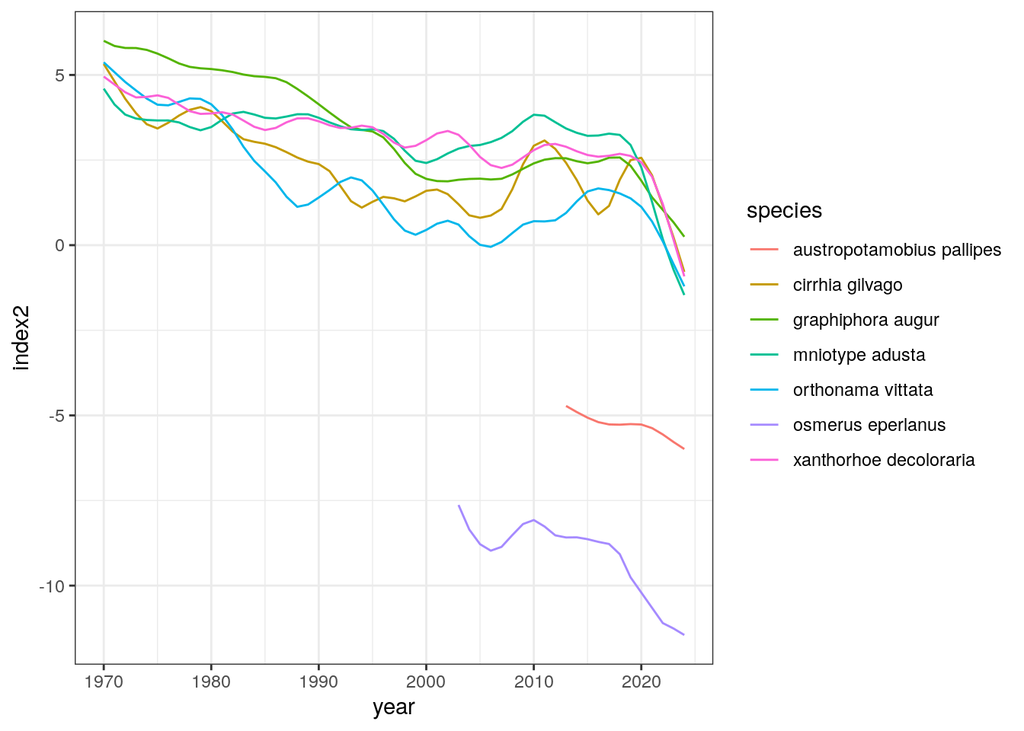

```r
ggplot(data = subset(data1, species %in% rownames(losers)),
       aes(x=year, y=index2, col=species)) +
    geom_line() +
  theme_bw()
```

- FW Inv
  - Austropotamobius pallipes : white clawed crayfish
- Moths
  - Cirrhia gilvago : dusky-lemon sallow
  - Graphiphora augur : double dart
  - Mniotype adusta : dark brocade
  - Orthonama vittata : oblique carpet
  - Xanthorhoe decoloraria : red carpet moth
- Fish
  - Osmerus eperlanus : european smelt

And the steepest increases

```r
head(winners <- subset(spTrends, ypk3_0 > +10))
```

```
##                      ypk3_0  ypk10_0     ypk3_5    ypk10_5
## ammodytes tobianus 14.46308 14.51748  -8.608955  -6.226158
## clupea harengus    29.27314 29.33972 -17.249054 -17.512237
## cobitis taenia     18.54572 18.52412  -5.677591  -5.575758
## phengaris arion    14.50895 14.50863  -1.059575  -1.061832
## potamanthus luteus 17.70567 17.70529  29.348460  29.344374
```

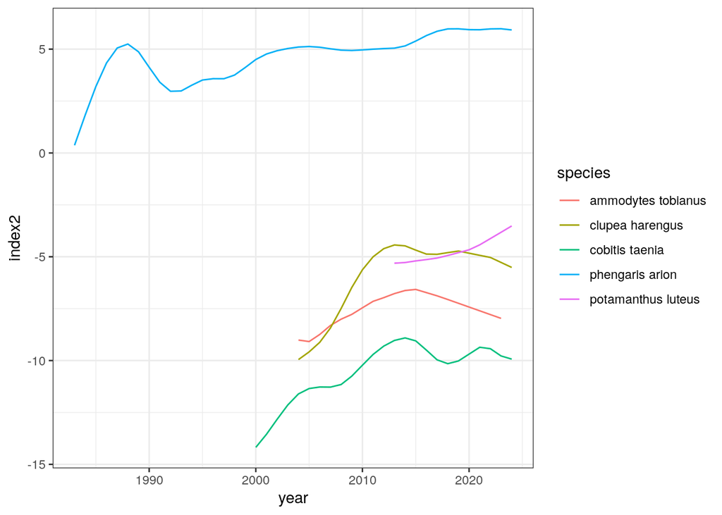

```r
ggplot(data = subset(data1, species %in% rownames(winners)),
       aes(x=year, y=index2, col=species)) +
    geom_line() +
  theme_bw()
```

* 5 species

- Fish
  - Ammodytes tobianus - Lesser sandeel
  - Clupea harengus : atlantic herring
  - Cobitis taenia : spined loach
- Butterflies
  - Phengaris arion : large blue
- FW Inv
  - Potamanthus luteus : yellow mayfly

## Categories of change

Get the group identity and summarise into categories and report the values for each group

```r
spTrends$group  <- data1$group[match(rownames(spTrends), data1$species)]
spTrends$survey <- data1$survey[match(rownames(spTrends), data1$species)]

spTrends$longTrendCat <- cut(spTrends$ypk3_0,
                         breaks = c(-Inf, -2.73, -1.14, +1.16, +2.81, Inf),
                         labels = c("Strong decrease", "Weak decrease", "Little change", "Weak increase", "Strong increase"))
summary(spTrends$longTrendCat)
```

```
## Strong decrease   Weak decrease   Little change   Weak increase Strong increase
##              77              36              20              10              18
```

```r
spTrends$shortTrendCat <- cut(spTrends$ypk3_5,
                         breaks = c(-Inf, -2.73, -1.14, +1.16, +2.81, Inf),
                         labels = c("Strong decrease", "Weak decrease", "Little change", "Weak increase", "Strong increase"))
summary(spTrends$shortTrendCat)
```

```
## Strong decrease   Weak decrease   Little change   Weak increase Strong increase
##              74              11              16              17              40
##            NA's
##               3
```

```r
with(spTrends, table(group, longTrendCat))
```

```
##                   longTrendCat
## group              Strong decrease Weak decrease Little change Weak increase
##   birds                         20            10             6             3
##   bumblebees                     0             0             0             0
##   butterflies                    7             8             2             2
##   fish                           4             0             1             0
##   fw invertebrates               1             0             0             0
##   mammals                        2             0             3             1
##   moths                         43            18             8             4
##   vascular plants                0             0             0             0
##                   longTrendCat
## group              Strong increase
##   birds                          5
##   bumblebees                     1
##   butterflies                    2
##   fish                           3
##   fw invertebrates               1
##   mammals                        2
##   moths                          3
##   vascular plants                1
```

```r
with(spTrends, table(group, shortTrendCat))
```

```
##                   shortTrendCat
## group              Strong decrease Weak decrease Little change Weak increase
##   birds                         19             6             7             5
##   bumblebees                     1             0             0             0
##   butterflies                   13             1             1             2
##   fish                           6             0             1             0
##   fw invertebrates               1             0             0             0
##   mammals                        1             1             4             1
##   moths                         33             3             3             9
##   vascular plants                0             0             0             0
##                   shortTrendCat
## group              Strong increase
##   birds                          5
##   bumblebees                     0
##   butterflies                    4
##   fish                           1
##   fw invertebrates               1
##   mammals                        1
##   moths                         27
##   vascular plants                1
```

```r
write.csv(spTrends, file = file.path(modeldir,"spTrends_d6a_to2024_120326.csv"), row.names = TRUE)
```

Summarise species trends - based on categorisation of change from knots per 3 year model

```r
spTrend_grp <- spTrends %>%
  select(group, longTrendCat, shortTrendCat) %>%
  melt(id.vars = "group") %>%
  group_by(group, variable, value) %>%
  summarise(n_spp = n()) %>%
  group_by(group, variable) %>%
  mutate(pct_spp = n_spp/sum(n_spp[!is.na(value)]))
spTrend_sum <- spTrends %>%
  select(group, longTrendCat, shortTrendCat) %>%
  melt(id.vars = "group") %>%
  group_by(variable, value) %>%
  summarise(n_spp = n()) %>%
  group_by(variable) %>%
  mutate(pct_spp = n_spp/sum(n_spp[!is.na(value)]),
         group = "all") %>%
  full_join(spTrend_grp) %>%
  rename(period = variable, trend_category = value) %>%
  mutate(trend_category =
           factor(trend_category,
                  levels = c("Strong decrease", "Weak decrease", "Little change",
                             "Weak increase", "Strong increase"))) %>%
  arrange(group, period, trend_category)
write.csv(spTrend_sum, file = file.path(modeldir, "spTrends_d6a_to2024_summary120326.csv"), row.names = FALSE)
```